# AS2-2: 股市動態

Group-00

2022-03-09 23:59:35

🌷 使用長期股價資料，這份作業的學習重點是：

- 使用`lapply()`對集合物件做重複的運算
- 使用折線圖檢視時間序列資料
- 在折線圖中增加更多序列進行比較

First of all, we `read.csv()` the following data files + `data/IBMStock.csv` + `data/GEStock.csv` + `data/ProcterGambleStock.csv` + `data/CocaColaStock.csv` + `data/BoeingStock.csv`

```r
L = list(
  IBM = read.csv("data/IBMStock.csv"),
  GE = read.csv("data/GEStock.csv"),
  PnG = read.csv("data/ProcterGambleStock.csv"),
  Coke = read.csv("data/CocaColaStock.csv"),
  Boeing = read.csv("data/BoeingStock.csv"))
```

We say a `list` is a collective object because it accommodate more than one sub-elements. Collectives are also regarded as iteratives, because we can apply some function on each of their elements repeatedly. For examples …

🌻 `lapply(x, fun)` applies fun to each element of `x` and return the results in a list

```r
lapply(L, class)
```

```
$IBM
[1] "data.frame"

$GE
[1] "data.frame"

$PnG
[1] "data.frame"

$Coke
[1] "data.frame"

$Boeing
[1] "data.frame"
```

🌻 `sapply(x, fun)` do the same thing as `lapply` plus it simplified the resultant object whenever it’s possible …

```r
sapply(L, class)
```

```
         IBM           GE          PnG         Coke       Boeing
"data.frame" "data.frame" "data.frame" "data.frame" "data.frame"
```

Here it returns a named vector which is simpler than a list.

```r
sapply(L, names)
```

```
     IBM          GE           PnG          Coke         Boeing
[1,] "Date"       "Date"       "Date"       "Date"       "Date"
[2,] "StockPrice" "StockPrice" "StockPrice" "StockPrice" "StockPrice"
```

In one line of code, we see that there are two columns `Date` and `StockPrice` in each of these data frames

Besides the build in functions, we can define our own functions, For an example …

```r
L = lapply(L, function(df) {
  df$Date =  as.Date(df$Date, format="%m/%d/%y")
  df
  } )
```

We define and apply a function that takes a data frame `df`, converts the `Date` column and returns the data frame. When we apply it to `L`, we accomplish 5 date conversion operations in one shoot.

You’d find it easier in answering the following questions by `lapply` and `sapply`.

### Section-1 Summary Statistics

**§ 1.1** Our five datasets all have the same number of observations. How many observations are there in each data set?

```r
#480 observations
IBM=read.csv('data/IBMstock.csv')
GE=read.csv('data/GEstock.csv')
PG=read.csv('data/ProcterGambleStock.csv')
CO=read.csv('data/CocaColastock.csv')
BOE=read.csv('data/Boeingstock.csv')
lapply(L, nrow)
```

```
$IBM
[1] 480

$GE
[1] 480

$PnG
[1] 480

$Coke
[1] 480

$Boeing
[1] 480
```

**§ 1.2** What is the earliest year in our datasets?

```r
#1970-01-01

#轉換成字串再轉換成Date
IBM$Date=as.character(IBM$Date) %>% as.Date('%m/%d/%y')
GE$Date=as.character(GE$Date) %>% as.Date('%m/%d/%y')
PG$Date=as.character(PG$Date) %>% as.Date('%m/%d/%y')
CO$Date=as.character(CO$Date) %>% as.Date('%m/%d/%y')
BOE$Date=as.character(BOE$Date) %>% as.Date('%m/%d/%y')
lapply(L, function(df){
  min(df$Date)
})
```

```
$IBM
[1] "1970-01-01"

$GE
[1] "1970-01-01"

$PnG
[1] "1970-01-01"

$Coke
[1] "1970-01-01"

$Boeing
[1] "1970-01-01"
```

**§ 1.3** What is the latest year in our datasets?

```r
#算出IBM最近的日期
max (IBM$Date)
```

```
[1] "2009-12-01"
```

**§ 1.4** What is the mean stock price of IBM over this time period?

```r
#算出IBM平均股價
mean(IBM$StockPrice)
```

```
[1] 144.4
```

**§ 1.5** What is the minimum stock price of General Electric (GE) over this time period?

```r
#算出GE最低股價
min(GE$StockPrice)
```

```
[1] 9.294
```

**§ 1.6** What is the maximum stock price of Coca-Cola over this time period?

```r
#算出CO最高股價
max(CO$StockPrice)
```

```
[1] 146.6
```

**§ 1.7** What is the median stock price of Boeing over this time period?

```r
#算出BOE股價中位數
median(BOE$StockPrice)
```

```
[1] 44.88
```

**§ 1.8** What is the standard deviation of the stock price of Procter & Gamble over this time period?

```r
#算出PG股價標準差
sd(PG$StockPrice)
```

```
[1] 18.19
```

### Section-2 Visualizing Stock Dynamics

**§ 2.1** Around what year did Coca-Cola has its highest stock price in this time period? Around what year did Coca-Cola has its lowest stock price in this time period?

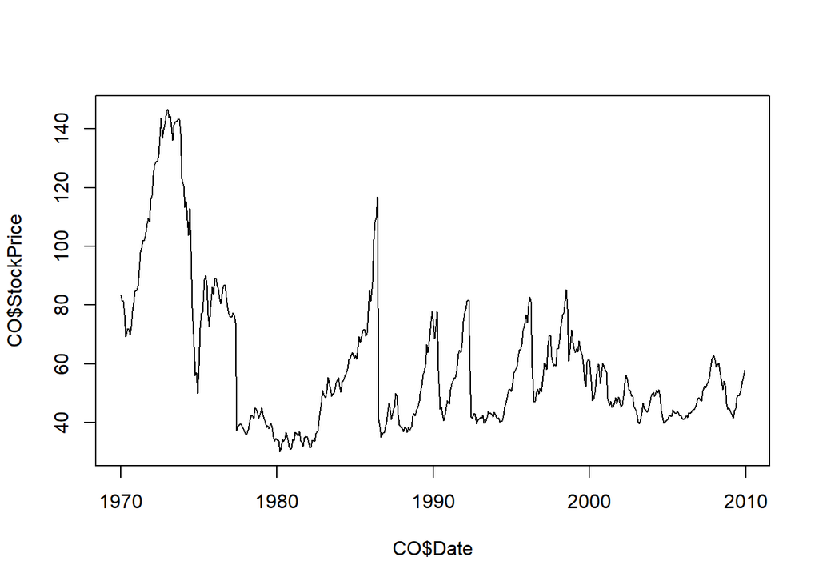

```r
plot(CO$Date, CO$StockPrice, type='l') #type='l'代表線圖
```

```r
#算出CO最高股價的日期
subset(CO$Date, CO$StockPrice == max(CO$StockPrice))
```

```
[1] "1973-01-01"
```

```r
#算出CO最低股價的日期
subset(CO$Date, CO$StockPrice == min(CO$StockPrice))
```

```
[1] "1980-03-01"
```

```r
#max:1973-01-01,min:1980-03-01
```

**§ 2.2** In March of 2000, the technology bubble burst, and a stock market crash occurred. According to this plot, which company’s stock dropped more?

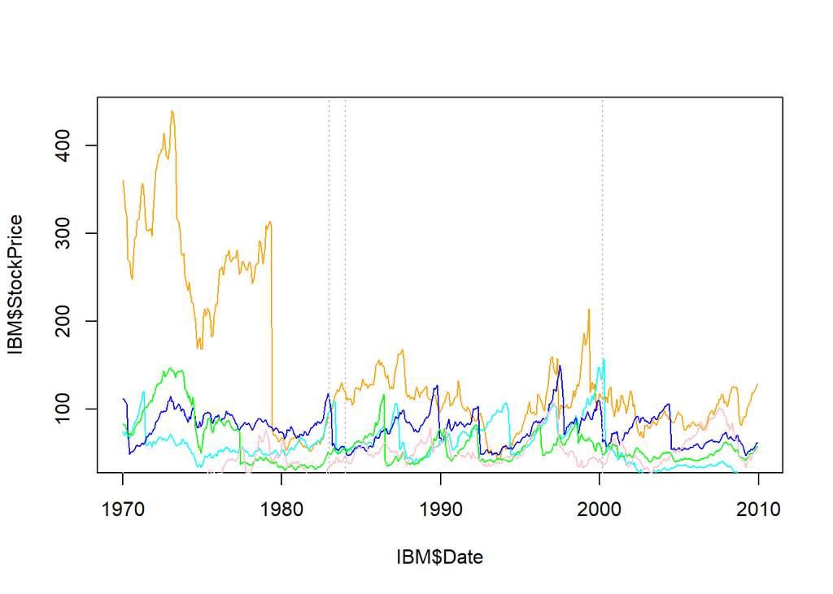

```r
plot(IBM$Date, IBM$StockPrice,type='l',col='orange')
#畫一張圖(不要再加一個plot，會畫第二張圖)
lines(GE$Date, GE$StockPrice,type='l',col='cyan')
lines(PG$Date, PG$StockPrice,type='l',col='blue')
lines(CO$Date, CO$StockPrice,type='l',col='green')
lines(BOE$Date, BOE$StockPrice,type='l',col='pink')
abline(v=as.Date(c("2000-03-01","1983-01-01","1984-01-01")),col='gray',lty=3)  #v代表垂直 #哪一些日期要畫輔助線 #先定義字串向量再用as.Date住換成日期
```

```r
#PG
```

**§ 2.3** (a) Around 1983, the stock for one of these companies (Coca-Cola or Procter and Gamble) was going up, while the other was going down. Which one was going up?

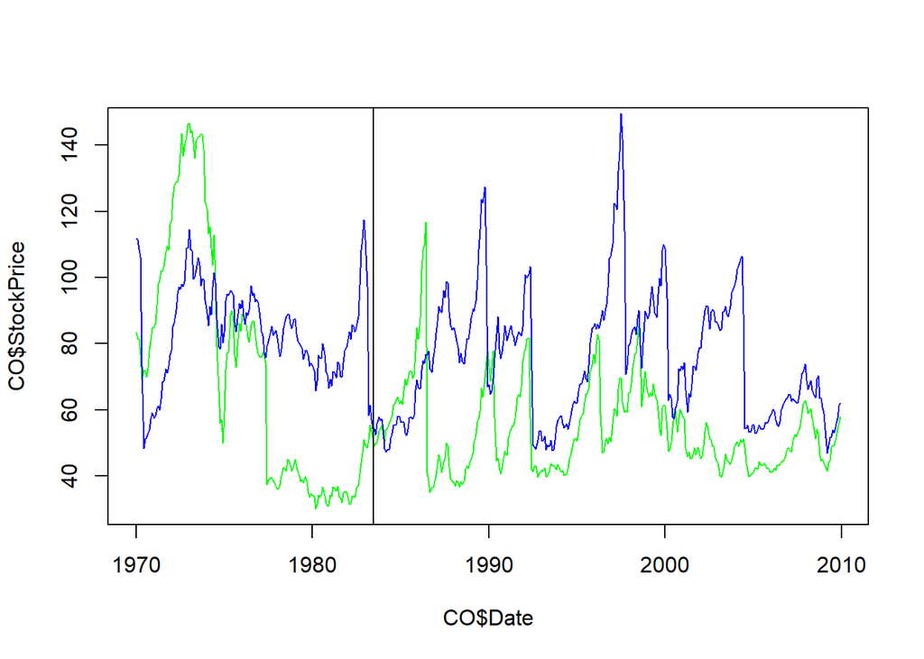

```r
plot(CO$Date,CO$StockPrice,type = "l",col="green")
lines(PG$Date, PG$StockPrice,col="blue")
abline(v=as.Date(c("1983-06-15")))
```

```r
#Coca-Cola
```

2. In the time period shown in the plot, which stock generally has lower values?

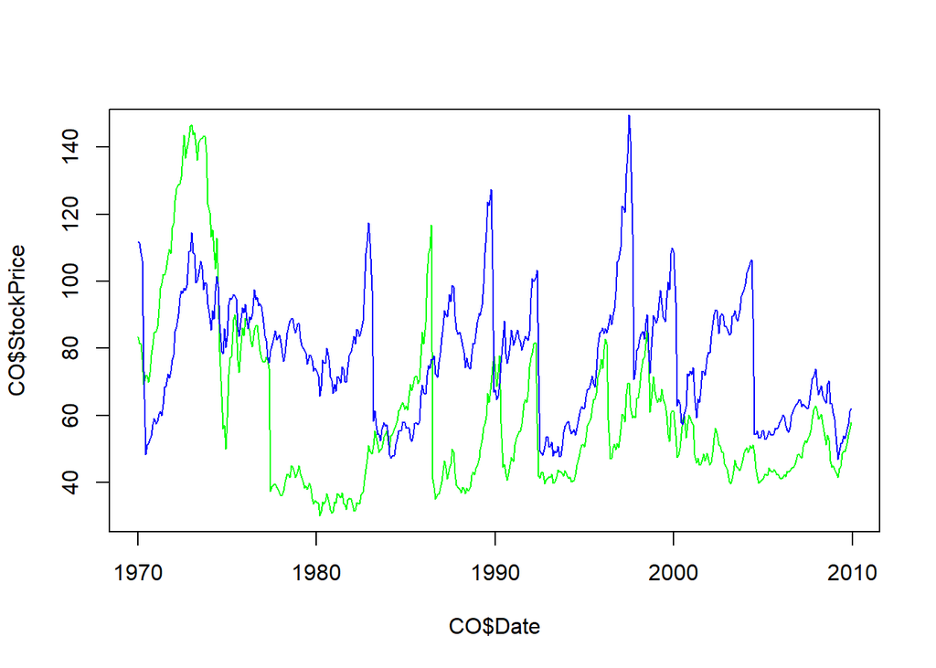

```r
plot(CO$Date,CO$StockPrice,type = "l",col="green")
lines(PG$Date, PG$StockPrice,col="blue")
```

```r
#Coca-Cola
```

### Section-3 Visualizing Stock Dynamics 1995-2005

**§ 3.1** Which stock fell the most right after the technology bubble burst in March 2000?

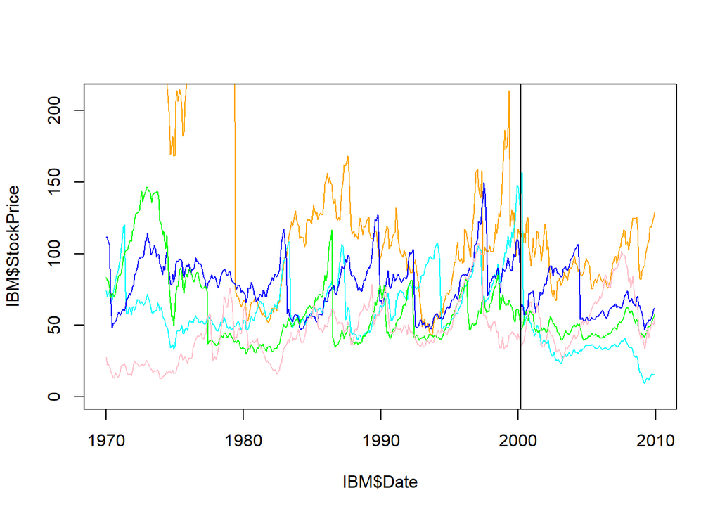

```r
plot(IBM$Date, IBM$StockPrice,type='l',col='orange', ylim=c(0,210))
lines(GE$Date, GE$StockPrice,type='l',col='cyan')
lines(PG$Date, PG$StockPrice,type='l',col='blue')
lines(CO$Date, CO$StockPrice,type='l',col='green')
lines(BOE$Date, BOE$StockPrice,type='l',col='pink')
abline(v=as.Date("2000-03-01"))
```

```r
#GE
```

**§ 3.2** Which stock reaches the highest value in the time period 1995-2005?

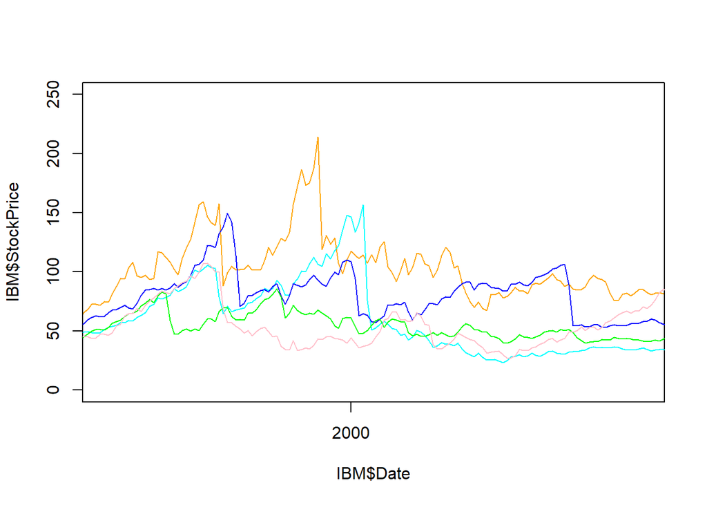

```r
plot(IBM$Date, IBM$StockPrice,type='l',col='orange', xlim=as.Date(c('1995-01-01','2005-12-01')),ylim=c(0,250)) #設定y軸區域
lines(GE$Date, GE$StockPrice,type='l',col='cyan')
lines(PG$Date, PG$StockPrice,type='l',col='blue')
lines(CO$Date, CO$StockPrice,type='l',col='green')
lines(BOE$Date, BOE$StockPrice,type='l',col='pink')
```

```r
#IBM
```

**§ 3.3** In October of 1997, there was a global stock market crash that was caused by an economic crisis in Asia. Comparing September 1997 to November 1997, which companies saw a decreasing trend in their stock price? (Select all that apply.)

```r
IBM$StockPrice[IBM$Date %in% as.Date(c("1997-09-01","1997-11-01"))]
```

```
[1] 101.5 102.2
```

```r
GE$StockPrice[GE$Date %in% as.Date(c("1997-09-01","1997-11-01"))]
```

```
[1] 67.63 69.56
```

```r
PG$StockPrice[PG$Date %in% as.Date(c("1997-09-01","1997-11-01"))]
```

```
[1] 114.1  73.4
```

```r
CO$StockPrice[CO$Date %in% as.Date(c("1997-09-01","1997-11-01"))]
```

```
[1] 59.31 59.40
```

```r
BOE$StockPrice[BOE$Date %in% as.Date(c("1997-09-01","1997-11-01"))]
```

```
[1] 54.10 48.34
```

```r
#PG.BOE
```

**§ 3.4** In the last two years of this time period (2004 and 2005) which stock seems to be performing the best, in terms of increasing stock price?

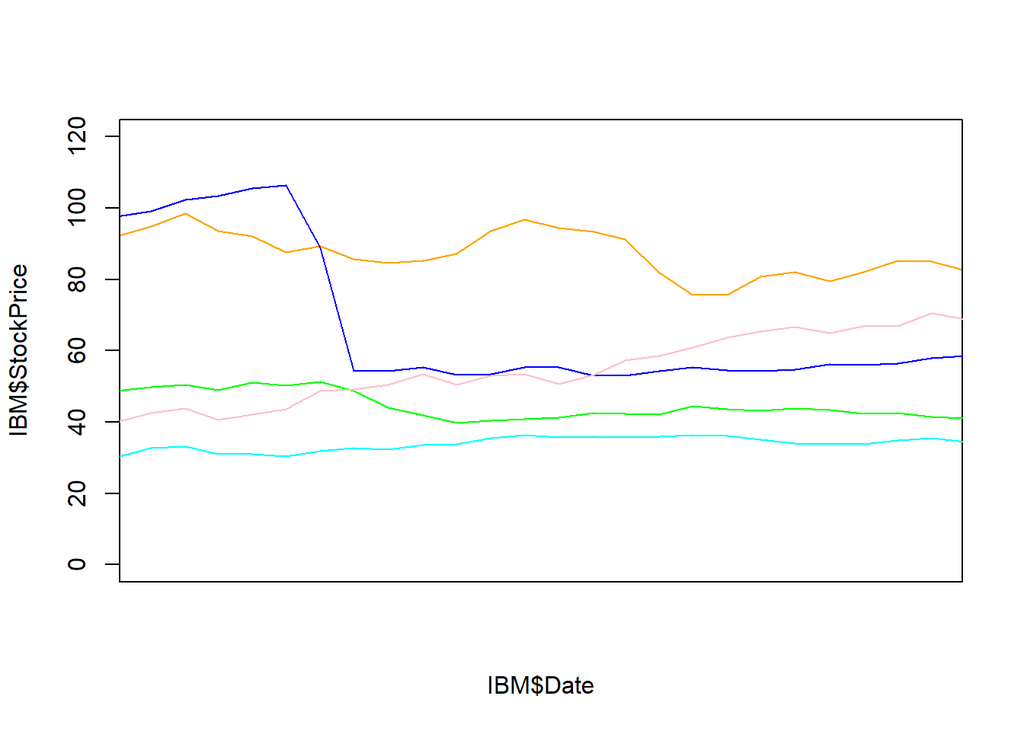

```r
plot(IBM$Date, IBM$StockPrice,type='l',col='orange', xlim=as.Date(c('2004-01-01','2005-12-01')),ylim=c(0,120)) #設定y軸區域
lines(GE$Date, GE$StockPrice,type='l',col='cyan')
lines(PG$Date, PG$StockPrice,type='l',col='blue')
lines(CO$Date, CO$StockPrice,type='l',col='green')
lines(BOE$Date, BOE$StockPrice,type='l',col='pink')
```

```r
#BOE
```

### Section-4 Monthly Trends

**§ 4.1** For IBM, compare the monthly averages to the overall average stock price. In which months has IBM historically had a higher stock price (on average)? Select all that apply.

```r
tapply(IBM$StockPrice,format(IBM$Date,'%m'),mean) #用format把IBM轉成月份再算出各月平均
```

```
   01    02    03    04    05    06    07    08    09    10    11    12
150.2 152.7 152.4 152.1 151.5 139.1 139.1 140.1 139.1 137.3 138.0 140.8
```

```r
mean(IBM$StockPrice)
```

```
[1] 144.4
```

```r
#1.2.3.4.5月
```

**§ 4.2** General Electric and Coca-Cola both have their highest average stock price in the same month. Which month is this?

```r
tapply(GE$StockPrice,format(GE$Date,'%m'),mean) #用format把GE轉成月份再算出各月平均
```

```
   01    02    03    04    05    06    07    08    09    10    11    12
62.05 62.52 63.15 64.48 60.87 56.47 56.73 56.50 56.24 56.24 57.29 59.10
```

```r
tapply(CO$StockPrice,format(CO$Date,'%m'),mean)
```

```
   01    02    03    04    05    06    07    08    09    10    11    12
60.37 60.73 62.07 62.69 61.44 60.81 58.98 58.88 57.60 57.94 59.10 59.73
```

```r
#4月
```

**§ 4.3** For the months of December and January, every company’s average stock is higher in one month and lower in the other. In which month are the stock prices lower?

```r
sapply(L,function(df)(tapply(df$StockPrice,format(df$Date,'%m'),mean))) #sapply五支股票1至12月作排列 #sapply(x,fun)對x裡面的每一個子物件執行fun功能並把輸出整理成矩陣
```

```
     IBM    GE   PnG  Coke Boeing
01 150.2 62.05 79.62 60.37  46.51
02 152.7 62.52 79.03 60.73  46.89
03 152.4 63.15 77.35 62.07  46.88
04 152.1 64.48 77.69 62.69  47.05
05 151.5 60.87 77.86 61.44  48.14
06 139.1 56.47 77.39 60.81  47.39
07 139.1 56.73 76.65 58.98  46.55
08 140.1 56.50 76.82 58.88  46.86
09 139.1 56.24 76.62 57.60  46.30
10 137.3 56.24 76.68 57.94  45.22
11 138.0 57.29 78.46 59.10  45.15
12 140.8 59.10 78.30 59.73  46.17
```

```r
#12月
```

##### ● NINJA’s DOJO ●

By combining `tapply` and `sapply`, we can acquire the monthly average stock prices for every stocks …

```r
mx = sapply(L, function(df) {
  tapply(df$StockPrice, format(df$Date, "%m"), mean) })
mx
```

```
     IBM    GE   PnG  Coke Boeing
01 150.2 62.05 79.62 60.37  46.51
02 152.7 62.52 79.03 60.73  46.89
03 152.4 63.15 77.35 62.07  46.88
04 152.1 64.48 77.69 62.69  47.05
05 151.5 60.87 77.86 61.44  48.14
06 139.1 56.47 77.39 60.81  47.39
07 139.1 56.73 76.65 58.98  46.55
08 140.1 56.50 76.82 58.88  46.86
09 139.1 56.24 76.62 57.60  46.30
10 137.3 56.24 76.68 57.94  45.22
11 138.0 57.29 78.46 59.10  45.15
12 140.8 59.10 78.30 59.73  46.17
```

❓ Can you see how it works?

🌻 `apple()` applies a function to a two dimensional object in either row or column direction (specified by its second argument, see online help for detail.)

```r
apply(mx, 2, which.max)
```

```
   IBM     GE    PnG   Coke Boeing
     2      4      1      4      5
```

So we can answer questions `4.1` and `4.2` in one shoot.

To answer `4.3` we need to compare the monthly averages of January and December for the 5 stocks. We simply use an index that select the 1st and the 12th rows of `mx` …

```r
mx[c(1,12),]
```

```
     IBM    GE   PnG  Coke Boeing
01 150.2 62.05 79.62 60.37  46.51
12 140.8 59.10 78.30 59.73  46.17
```

🌷 This is what we mean by **analysis** - organizing data in a way that serves our interest.

💡 The `apply` Family：  
R’s major mechanism for iteration is the `apply()` functions …  
■ `tapply(x, category, fun)` applies `fun` to `x` by `category`  
■ `lapply(x, fun)` applies `fun` to each elements of `x` and returns a list  
■ `sapply(x, fun)` same as `lapply` but simply the return object whenever possible  
■ `apply(x, margin, fun)` applies `fun` to every row (column) of `x` when margin is set to 1 (2)